# Exercise 5 - Partial Dependence Plots (XAI)

Daniel Reinón García Carlos Pérez Faus Miguel Abarca Casares

## 1. One-Dimensional Partial Dependence Plot (PDP)

We apply a random forest model to predict the number of bike rentals (`cnt`) using variables like temperature, humidity, wind speed, and days since 2011 (`instant`).

```r
library(randomForest)
library(tidyverse)
library(iml)
library(grid)
library(gridExtra)
```

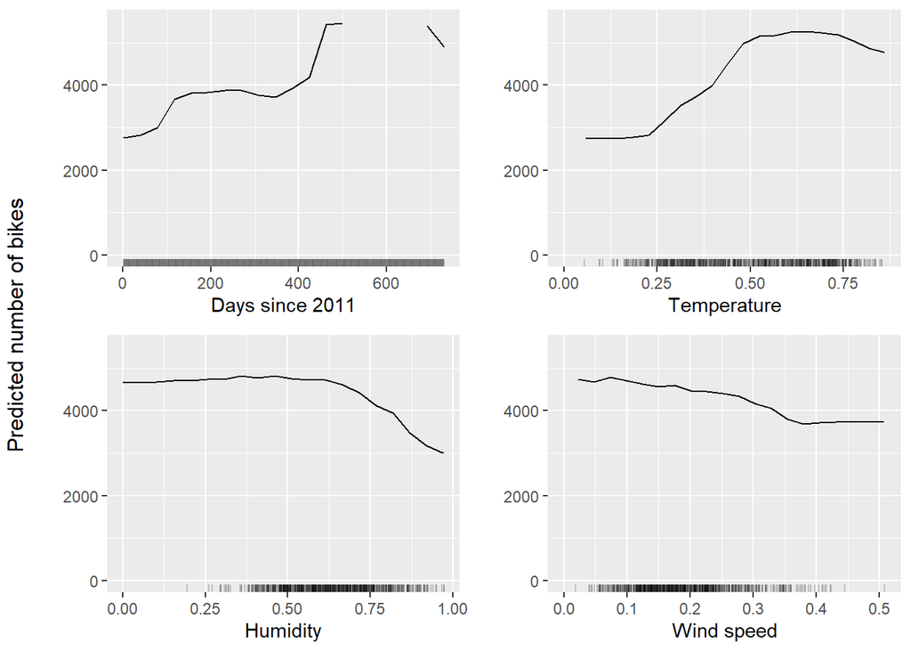

```r
# Load data
day <- read.csv("day.csv")

# Fit random forest model
model_day <- randomForest(cnt ~ ., data = day[, c("cnt", "instant", "temp", "hum", "windspeed")], ntree = 100)

# Wrap in Predictor for iml
predictor <- Predictor$new(model_day, data = day[, c("instant", "temp", "hum", "windspeed")], y = day$cnt)

# PDP for days since 2011
pdp <- FeatureEffect$new(predictor, feature="instant", method = "pdp")
p1 <- pdp$plot() +
  scale_x_continuous('Days since 2011', limits = c(0, NA)) +
  scale_y_continuous("", limits = c(0, 5500))
# PDP for temperature
pdp$set.feature("temp")
p2 <- pdp$plot() +
  scale_x_continuous('Temperature', limits = c(0, NA)) +
  scale_y_continuous('', limits = c(0, 5500))
# PDP for humidity
pdp$set.feature("hum")
p3 <- pdp$plot() +
  scale_x_continuous('Humidity', limits = c(0, NA)) +
  scale_y_continuous('', limits = c(0, 5500))
# PDP for windspeed
pdp$set.feature("windspeed")
p4 <- pdp$plot() +
  scale_x_continuous('Wind speed', limits = c(0, NA)) +
  scale_y_continuous('', limits = c(0, 5500))
# Combine plots
plot_grid_1d <- arrangeGrob(p1 + ylab("Predicted number of bikes"),
                            p2 + ylab(NULL),
                            p3 + ylab(NULL),
                            p4 + ylab(NULL),
                            ncol = 2)

grid.arrange(plot_grid_1d, left = textGrob("Predicted number of bikes", rot = 90, gp = gpar(fontsize = 12)))
```

### Interpretation

- **Days since 2011 (`instant`)** shows a clear upward trend. This likely reflects an overall growth in the use of the bike-sharing service over time, potentially due to increasing popularity, improvements in infrastructure, or seasonal accumulation effects.
- **Temperature (`temp`)** has a strong positive influence. As temperature rises, predicted bike rentals increase sharply, peaking around moderate-to-high temperatures. This implies ideal biking conditions at pleasant temperatures, with a slight drop-off in extremely hot conditions.
- **Humidity (`hum`)** negatively impacts the predicted number of bike rentals, especially beyond 60–70% humidity. This suggests that people are less likely to bike in uncomfortable, humid conditions.
- **Windspeed** exhibits a consistent negative effect. As wind speed increases, predicted bike rentals decrease, likely due to the greater physical effort required or safety concerns in high-wind conditions.

## 2. Two-Dimensional PDP: Temperature vs Humidity

We explore the joint effect of temperature and humidity using a 2D PDP and `geom_tile`.

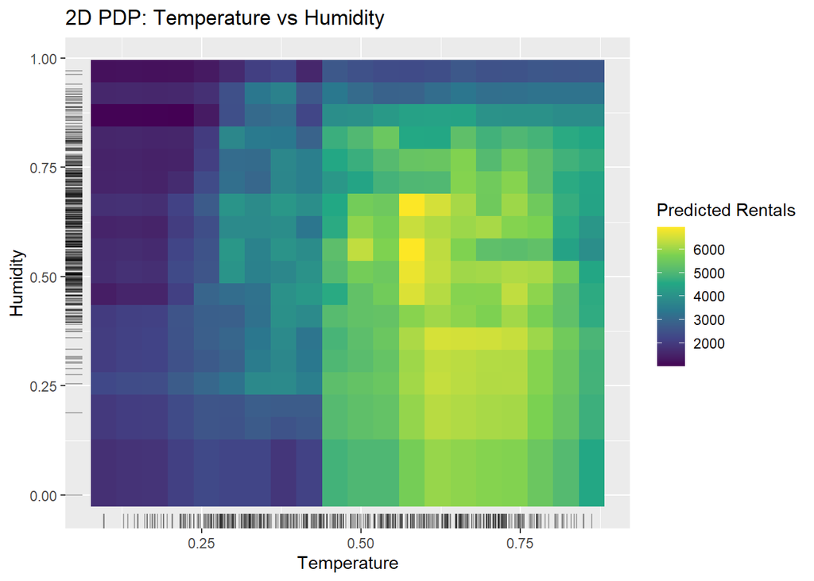

```r
# Subsample
set.seed(123)
day_sample <- day[sample(nrow(day), 500), ]

# Model
model_sample <- randomForest(cnt ~ temp + hum, data = day_sample, ntree = 100)

# Predictor
predictor_2d <- Predictor$new(model_sample, data = day_sample[, c("temp", "hum")], y = day_sample$cnt)

# 2D PDP
pd <- FeatureEffect$new(predictor_2d, feature = c("temp", "hum"), method = "pdp")

# Plot
pd_data <- pd$plot()$data

ggplot(pd_data, aes(x = temp, y = hum, fill = .value)) +
  geom_tile() +
  geom_rug(data = day_sample, aes(x = temp), sides = "b", inherit.aes = FALSE, alpha = 0.3) +
  geom_rug(data = day_sample, aes(y = hum), sides = "l", inherit.aes = FALSE, alpha = 0.3) +
  scale_fill_viridis_c() +
  labs(title = "2D PDP: Temperature vs Humidity",
       x = "Temperature",
       y = "Humidity",
       fill = "Predicted Rentals")
```

### Interpretation

- The model predicts the most rentals when **temperature is moderate to warm (≈ 0.55–0.75)** and **humidity is moderate (≈ 0.35–0.60)**.
- **Low temperatures (< 0.30)** suppress demand even if humidity is favourable.
- **High humidity (> 0.80)** strongly reduces predicted rentals at any temperature.
- The rug plots show that most observed days cluster within the moderate ranges; predictions in the darker corners are based on fewer observations and are therefore less certain.

## 3. PDP to Explain House Price

We apply a random forest model to predict house prices using features like the number of bedrooms, bathrooms, square footage, and year built.

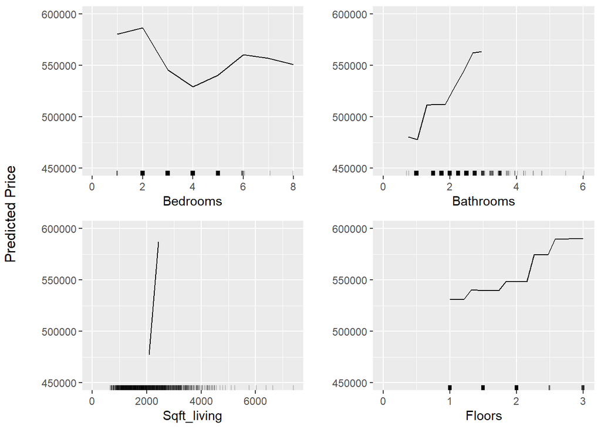

```r
# (packages loaded earlier remain in session)

# Load & subsample data
kc <- read.csv("kc_house_data.csv")
kc_sample <- kc[sample(nrow(kc), 1000), ]

# Fit RF
rf_kc <- randomForest(price ~ bedrooms + bathrooms + sqft_living + sqft_lot + floors + yr_built,
                      data = kc_sample, ntree = 100)

# Predictor wrapper
pred_kc <- Predictor$new(
  rf_kc,
  data = kc_sample[, c("bedrooms", "bathrooms", "sqft_living", "sqft_lot", "floors", "yr_built")],
  y    = kc_sample$price
)

# Features for 1‑D PDP
one_d_feats <- c("bedrooms", "bathrooms", "sqft_living", "floors")
plots_1d <- lapply(one_d_feats, function(f) {
  FeatureEffect$new(pred_kc, feature = f, method = "pdp")$plot() +
    scale_x_continuous(tools::toTitleCase(f), limits = c(0, NA)) +
    scale_y_continuous("", limits = c(450000, 600000))
})
grid <- arrangeGrob(plots_1d[[1]], plots_1d[[2]], plots_1d[[3]], plots_1d[[4]], ncol = 2)
grid.arrange(grid, left = textGrob("Predicted Price", rot = 90, gp = gpar(fontsize = 12)))
```